# RESI for mgcv gam/bam: null check and point-estimate calibration

2026-11-20

# Design

Simulation from `tests/run_gam_calibration.R` (design and decisions: `notes/resi_gam.qmd`). Every scenario fits

`y ~ s(x1, k) + s(x2, k) + s(x3, k) + w + w0`, $k \in \{5, 10, 20\}$,

to Gaussian data with $x_1, x_2$ uniform and correlated through a Gaussian copula ($\rho = 0.5$, some concurvity), $x_3$ uniform and $w, w_0 \sim N(0, 1)$ independent. `s(x3)` and `w0` are null.

| Scenario | Mean | Error SD | What it probes |
| --- | --- | --- | --- |
| base | $\sin(2\pi x_1) + 0.5x_2 + 0.2w$ | 1 | well-specified reference |
| step | $0.8\cdot 1(x_1 > 0.5) + 0.5x_2 + 0.2w$ | 1 | basis truncation error: T2 depends on $k$ |
| weak_curve | $\sin(2\pi x_1) + 0.25(2x_2 - 1)^2 + 0.2w$ | 1 | weak non-linear effect; REML $\hat\lambda \gg n$ at small $n$ |
| hetero | base | $\exp\{0.4w + 0.6(x_1 - 0.5)\}$ | heteroskedasticity: parametric and robust targets differ |

Each replicate draws one data set per scenario and $n \in \{200, 1000, 5000, 20000\}$ (500 replicates). The fits are `gam(method = "REML")` and, in the base scenario only, `bam()` (fREML), each **penalized** (mgcv default; the estimator under evaluation) and **unpenalized** (`fx = TRUE`, a regression spline with $k - 1$ df per smooth, for reference). Every fit is scored with two covariances:

- **Vp**: mgcv’s default (parametric, Bayesian) covariance, as used by `summary.gam`. Smooth RESI is `f2S(F, Ref.df, residual df, n)`; coefficient RESI is `t2S(t, residual df, n)`.
- **sandwich**: `vcov.gam(sandwich = TRUE)` substituted for `Vp` in `summary.gam`, same conversions.

**Target.** T2(k) is the Wald noncentrality per observation of the fixed-basis projection: let $b$ be the coefficients of the population least squares projection of $E[y \mid x]$ on the size-$k$ (default `tp`) bases, $e$ the working residual and $A = E[XX^\top]$. Then $S_j^2 = b_j^\top [V_{jj}]^{-1} b_j$ with

- parametric: $V = \sigma_k^2 A^{-1}$, $\sigma_k^2 = E[e^2]$ (the limit of `Vp`), column `S_T2`;
- robust: $V = A^{-1}E[XX^\top e^2]A^{-1}$ (the limit of the sandwich), column `S_T2r`.

They are computed from a noiseless sample of $2\times 10^5$, using $E[e^2 \mid x] = \mathrm{sd}(x)^2 + \{E[y\mid x] - Xb\}^2$. Vp estimates are compared with `S_T2` and sandwich estimates with `S_T2r`. The two coincide unless the working residual is heteroskedastic.

T2(k) targets for the non-null terms (parametric S_T2 and robust S_T2r, by k)

| scenario | term | S_T2.5 | S_T2r.5 | S_T2.10 | S_T2r.10 | S_T2.20 | S_T2r.20 |
| --- | --- | --- | --- | --- | --- | --- | --- |
| base | x1 | 0.6646 | 0.6647 | 0.6653 | 0.6653 | 0.6652 | 0.6652 |
| base | x2 | 0.1268 | 0.1268 | 0.1257 | 0.1257 | 0.1256 | 0.1256 |
| base | w | 0.1998 | 0.1998 | 0.1998 | 0.1998 | 0.1998 | 0.1998 |
| step | x1 | 0.3371 | 0.3388 | 0.3550 | 0.3557 | 0.3604 | 0.3607 |
| step | x2 | 0.1273 | 0.1272 | 0.1254 | 0.1253 | 0.1256 | 0.1256 |
| step | w | 0.1985 | 0.1985 | 0.1992 | 0.1992 | 0.1995 | 0.1995 |
| weak_curve | x1 | 0.6646 | 0.6647 | 0.6653 | 0.6653 | 0.6652 | 0.6652 |
| weak_curve | x2 | 0.0729 | 0.0729 | 0.0728 | 0.0728 | 0.0728 | 0.0728 |
| weak_curve | w | 0.1998 | 0.1998 | 0.1998 | 0.1998 | 0.1998 | 0.1998 |
| hetero | x1 | 0.5501 | 0.5614 | 0.5506 | 0.5626 | 0.5505 | 0.5626 |
| hetero | x2 | 0.1050 | 0.1067 | 0.1040 | 0.1057 | 0.1040 | 0.1057 |
| hetero | w | 0.1654 | 0.1289 | 0.1654 | 0.1289 | 0.1654 | 0.1289 |

# Null check

Rejection rates at 0.05 for the null smooth `s(x3)` and null coefficient `w0` ($k = 10$; all $k$ in the table). The grey band is $0.05 \pm 1.96$ MC SE.

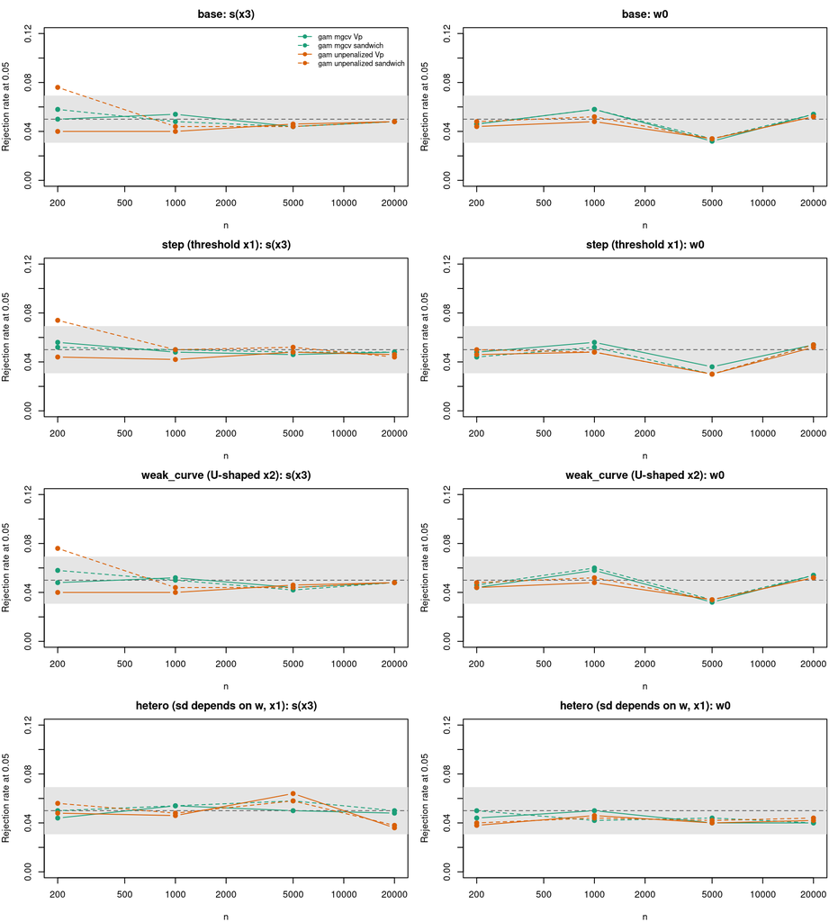

Null terms: rejection rate at 0.05

| scenario | term | k | method | n = 200 | n = 1000 | n = 5000 | n = 20000 |
| --- | --- | --- | --- | --- | --- | --- | --- |
| base | w0 | 5 | bam mgcv sandwich | 0.048 | 0.054 | 0.034 | 0.056 |
| base | w0 | 5 | bam mgcv Vp | 0.046 | 0.056 | 0.036 | 0.060 |
| base | w0 | 5 | bam unpenalized sandwich | 0.038 | 0.054 | 0.036 | 0.058 |
| base | w0 | 5 | bam unpenalized Vp | 0.042 | 0.050 | 0.034 | 0.060 |
| base | w0 | 5 | gam mgcv sandwich | 0.048 | 0.054 | 0.034 | 0.056 |
| base | w0 | 5 | gam mgcv Vp | 0.046 | 0.056 | 0.036 | 0.060 |
| base | w0 | 5 | gam unpenalized sandwich | 0.038 | 0.054 | 0.036 | 0.058 |
| base | w0 | 5 | gam unpenalized Vp | 0.042 | 0.050 | 0.034 | 0.060 |
| base | w0 | 10 | bam mgcv sandwich | 0.046 | 0.058 | 0.034 | 0.054 |
| base | w0 | 10 | bam mgcv Vp | 0.046 | 0.058 | 0.032 | 0.054 |
| base | w0 | 10 | bam unpenalized sandwich | 0.048 | 0.052 | 0.034 | 0.052 |
| base | w0 | 10 | bam unpenalized Vp | 0.044 | 0.048 | 0.034 | 0.052 |
| base | w0 | 10 | gam mgcv sandwich | 0.046 | 0.058 | 0.034 | 0.054 |
| base | w0 | 10 | gam mgcv Vp | 0.046 | 0.058 | 0.032 | 0.054 |
| base | w0 | 10 | gam unpenalized sandwich | 0.048 | 0.052 | 0.034 | 0.052 |
| base | w0 | 10 | gam unpenalized Vp | 0.044 | 0.048 | 0.034 | 0.052 |
| base | w0 | 20 | bam mgcv sandwich | 0.046 | 0.058 | 0.034 | 0.054 |
| base | w0 | 20 | bam mgcv Vp | 0.044 | 0.064 | 0.032 | 0.054 |
| base | w0 | 20 | bam unpenalized sandwich | 0.044 | 0.048 | 0.030 | 0.048 |
| base | w0 | 20 | bam unpenalized Vp | 0.036 | 0.048 | 0.030 | 0.052 |
| base | w0 | 20 | gam mgcv sandwich | 0.046 | 0.058 | 0.034 | 0.054 |
| base | w0 | 20 | gam mgcv Vp | 0.044 | 0.064 | 0.032 | 0.054 |
| base | w0 | 20 | gam unpenalized sandwich | 0.044 | 0.048 | 0.030 | 0.048 |
| base | w0 | 20 | gam unpenalized Vp | 0.036 | 0.048 | 0.030 | 0.052 |
| base | x3 | 5 | bam mgcv sandwich | 0.060 | 0.056 | 0.054 | 0.050 |
| base | x3 | 5 | bam mgcv Vp | 0.050 | 0.050 | 0.054 | 0.048 |
| base | x3 | 5 | bam unpenalized sandwich | 0.062 | 0.052 | 0.056 | 0.038 |
| base | x3 | 5 | bam unpenalized Vp | 0.048 | 0.058 | 0.060 | 0.038 |
| base | x3 | 5 | gam mgcv sandwich | 0.060 | 0.054 | 0.054 | 0.046 |
| base | x3 | 5 | gam mgcv Vp | 0.050 | 0.050 | 0.054 | 0.046 |

[output cut: 90 more lines]

# Calibration of the point estimates

MC mean of $\hat S$ against $n$ ($k = 10$). Solid black: parametric target `S_T2`; dashed black: robust target `S_T2r` (indistinguishable except in hetero). Error bars: $\pm 2$ MC SE.

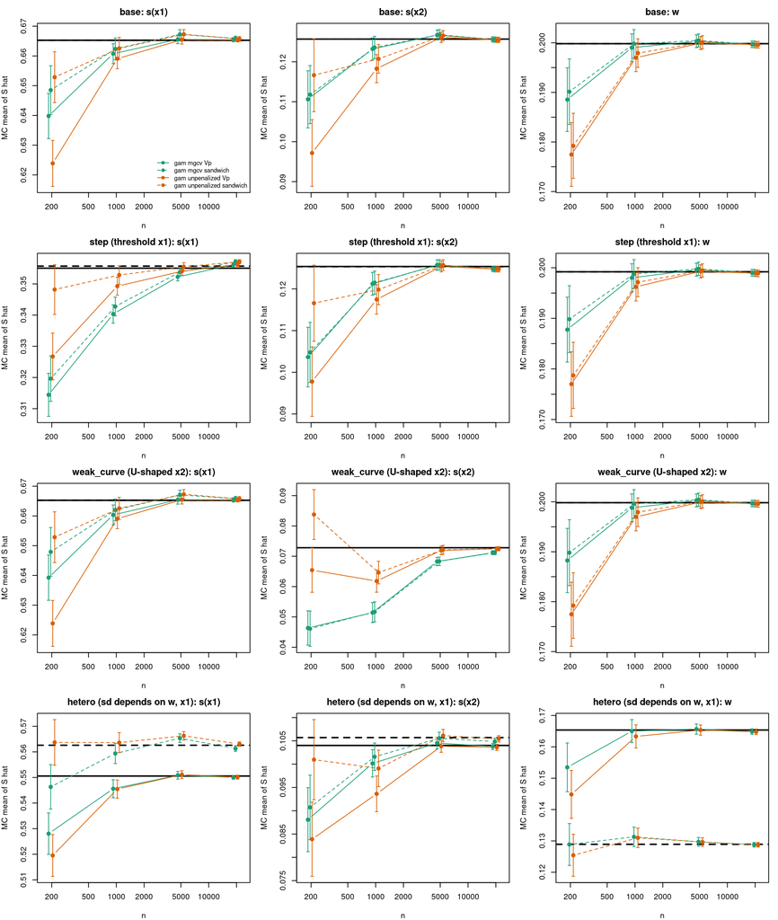

## Dependence on $k$ (step scenario)

With a threshold effect the basis cannot represent $f_1$, so T2(k) increases with $k$. The penalized estimator should track the target for its own $k$ (horizontal lines, same colour).

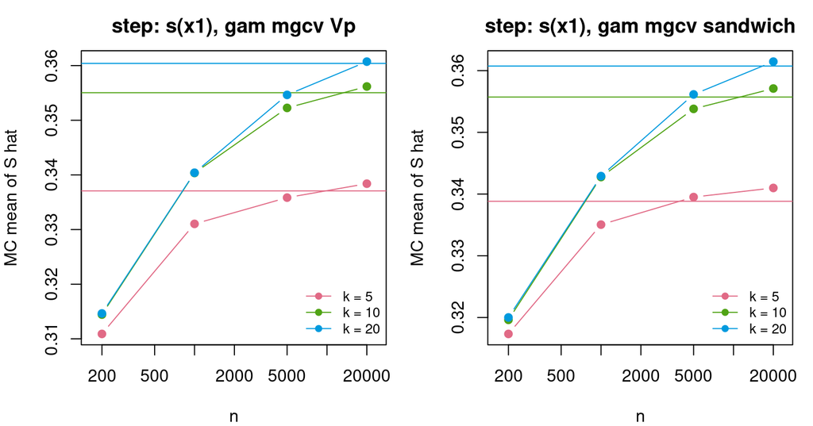

Relative bias of the MC mean of S hat against its T2(k) target (Vp: S_T2; sandwich: S_T2r)

| scenario | term | k | method | target | n = 5000 | n = 200 | n = 20000 | n = 1000 |
| --- | --- | --- | --- | --- | --- | --- | --- | --- |
| base | w | 5 | bam mgcv sandwich | 0.200 | 0.004 | -0.047 | -0.001 | 0.001 |
| base | w | 5 | bam mgcv Vp | 0.200 | 0.003 | -0.055 | -0.001 | -0.003 |
| base | w | 5 | bam unpenalized sandwich | 0.200 | 0.003 | -0.068 | -0.001 | -0.004 |
| base | w | 5 | bam unpenalized Vp | 0.200 | 0.002 | -0.077 | -0.001 | -0.008 |
| base | w | 5 | gam mgcv sandwich | 0.200 | 0.004 | -0.047 | -0.001 | 0.001 |
| base | w | 5 | gam mgcv Vp | 0.200 | 0.003 | -0.055 | -0.001 | -0.003 |
| base | w | 5 | gam unpenalized sandwich | 0.200 | 0.003 | -0.068 | -0.001 | -0.004 |
| base | w | 5 | gam unpenalized Vp | 0.200 | 0.002 | -0.077 | -0.001 | -0.008 |
| base | w | 10 | bam mgcv sandwich | 0.200 | 0.003 | -0.049 | -0.001 | 0.000 |
| base | w | 10 | bam mgcv Vp | 0.200 | 0.002 | -0.057 | -0.001 | -0.004 |
| base | w | 10 | bam unpenalized sandwich | 0.200 | 0.001 | -0.103 | -0.001 | -0.010 |
| base | w | 10 | bam unpenalized Vp | 0.200 | 0.001 | -0.112 | -0.001 | -0.014 |
| base | w | 10 | gam mgcv sandwich | 0.200 | 0.003 | -0.048 | -0.001 | 0.000 |
| base | w | 10 | gam mgcv Vp | 0.200 | 0.002 | -0.056 | -0.001 | -0.004 |
| base | w | 10 | gam unpenalized sandwich | 0.200 | 0.001 | -0.103 | -0.001 | -0.010 |
| base | w | 10 | gam unpenalized Vp | 0.200 | 0.001 | -0.112 | -0.001 | -0.014 |
| base | w | 20 | bam mgcv sandwich | 0.200 | 0.003 | -0.048 | -0.001 | 0.000 |
| base | w | 20 | bam mgcv Vp | 0.200 | 0.003 | -0.056 | -0.001 | -0.004 |
| base | w | 20 | bam unpenalized sandwich | 0.200 | -0.002 | -0.193 | -0.002 | -0.023 |
| base | w | 20 | bam unpenalized Vp | 0.200 | -0.002 | -0.200 | -0.002 | -0.028 |
| base | w | 20 | gam mgcv sandwich | 0.200 | 0.003 | -0.049 | -0.001 | 0.000 |
| base | w | 20 | gam mgcv Vp | 0.200 | 0.003 | -0.057 | -0.001 | -0.004 |
| base | w | 20 | gam unpenalized sandwich | 0.200 | -0.002 | -0.193 | -0.002 | -0.023 |
| base | w | 20 | gam unpenalized Vp | 0.200 | -0.002 | -0.200 | -0.002 | -0.028 |
| base | x1 | 5 | bam mgcv sandwich | 0.665 | 0.003 | -0.026 | 0.001 | -0.004 |
| base | x1 | 5 | bam mgcv Vp | 0.665 | 0.001 | -0.033 | 0.001 | -0.005 |
| base | x1 | 5 | bam unpenalized sandwich | 0.665 | 0.003 | -0.021 | 0.001 | -0.003 |
| base | x1 | 5 | bam unpenalized Vp | 0.665 | 0.001 | -0.032 | 0.001 | -0.004 |
| base | x1 | 5 | gam mgcv sandwich | 0.665 | 0.004 | -0.014 | 0.001 | 0.000 |
| base | x1 | 5 | gam mgcv Vp | 0.665 | 0.002 | -0.027 | 0.001 | -0.003 |

[output cut: 150 more lines]

# Is `Ref.df` the right bias correction?

The $-\text{df}$ correction removes the contribution of the estimator’s variance to $E[T]$. On the scale used by `f2S`, the diagnostic is the effective df, $E[F\,r\,(\text{rdf}-2)/\text{rdf}] - n S^2_{T2}$, compared with the MC mean of `Ref.df` (Vp only). Penalization also shrinks the signal part of $T$, so a negative gap mixes a too-large df with smoothing bias. The gap divided by $n$ is the bias of $\hat S^2$ before truncation. The MC SE of the effective df grows like $\sqrt{n} S$, so the check is informative only for the null and weak terms.

k = 10. Mean edf, mean Ref.df, and effective df = E[F Ref.df (rdf-2)/rdf] - n S_T2^2; S2_bias = (effective df - Ref.df) / n

| scenario | term | method | n | edf | ref_df | eff_df | eff_df_mcse | S2_bias |
| --- | --- | --- | --- | --- | --- | --- | --- | --- |
| base | x2 | bam mgcv Vp | 200 | 1.312 | 1.457 | 1.848 | 0.212 | 0.002 |
| base | x2 | bam mgcv Vp | 1000 | 1.275 | 1.411 | 1.769 | 0.347 | 0.000 |
| base | x2 | bam mgcv Vp | 5000 | 1.278 | 1.411 | 3.692 | 0.786 | 0.000 |
| base | x2 | bam mgcv Vp | 20000 | 1.319 | 1.475 | 2.350 | 1.675 | 0.000 |
| base | x2 | bam unpenalized Vp | 200 | 9.000 | 9.000 | 8.502 | 0.260 | -0.002 |
| base | x2 | bam unpenalized Vp | 1000 | 9.000 | 9.000 | 8.715 | 0.394 | 0.000 |
| base | x2 | bam unpenalized Vp | 5000 | 9.000 | 9.000 | 10.588 | 0.801 | 0.000 |
| base | x2 | bam unpenalized Vp | 20000 | 9.000 | 9.000 | 9.086 | 1.676 | 0.000 |
| base | x2 | gam mgcv Vp | 200 | 1.329 | 1.479 | 1.922 | 0.213 | 0.002 |
| base | x2 | gam mgcv Vp | 1000 | 1.293 | 1.437 | 1.779 | 0.348 | 0.000 |
| base | x2 | gam mgcv Vp | 5000 | 1.282 | 1.420 | 3.658 | 0.786 | 0.000 |
| base | x2 | gam mgcv Vp | 20000 | 1.299 | 1.449 | 2.121 | 1.675 | 0.000 |
| base | x2 | gam unpenalized Vp | 200 | 9.000 | 9.000 | 8.502 | 0.260 | -0.002 |
| base | x2 | gam unpenalized Vp | 1000 | 9.000 | 9.000 | 8.715 | 0.394 | 0.000 |
| base | x2 | gam unpenalized Vp | 5000 | 9.000 | 9.000 | 10.588 | 0.801 | 0.000 |
| base | x2 | gam unpenalized Vp | 20000 | 9.000 | 9.000 | 9.088 | 1.676 | 0.000 |
| base | x3 | bam mgcv Vp | 200 | 1.279 | 1.411 | 1.599 | 0.097 | 0.001 |
| base | x3 | bam mgcv Vp | 1000 | 1.272 | 1.404 | 1.626 | 0.096 | 0.000 |
| base | x3 | bam mgcv Vp | 5000 | 1.294 | 1.436 | 1.703 | 0.093 | 0.000 |
| base | x3 | bam mgcv Vp | 20000 | 1.303 | 1.444 | 1.751 | 0.123 | 0.000 |
| base | x3 | bam unpenalized Vp | 200 | 9.000 | 9.000 | 8.723 | 0.189 | -0.001 |
| base | x3 | bam unpenalized Vp | 1000 | 9.000 | 9.000 | 8.840 | 0.188 | 0.000 |
| base | x3 | bam unpenalized Vp | 5000 | 9.000 | 9.000 | 8.910 | 0.182 | 0.000 |
| base | x3 | bam unpenalized Vp | 20000 | 9.000 | 9.000 | 9.078 | 0.202 | 0.000 |
| base | x3 | gam mgcv Vp | 200 | 1.286 | 1.420 | 1.648 | 0.101 | 0.001 |
| base | x3 | gam mgcv Vp | 1000 | 1.278 | 1.413 | 1.621 | 0.097 | 0.000 |
| base | x3 | gam mgcv Vp | 5000 | 1.296 | 1.445 | 1.686 | 0.091 | 0.000 |
| base | x3 | gam mgcv Vp | 20000 | 1.311 | 1.459 | 1.752 | 0.123 | 0.000 |
| base | x3 | gam unpenalized Vp | 200 | 9.000 | 9.000 | 8.723 | 0.189 | -0.001 |
| base | x3 | gam unpenalized Vp | 1000 | 9.000 | 9.000 | 8.840 | 0.188 | 0.000 |
| base | x3 | gam unpenalized Vp | 5000 | 9.000 | 9.000 | 8.910 | 0.182 | 0.000 |
| base | x3 | gam unpenalized Vp | 20000 | 9.000 | 9.000 | 9.080 | 0.202 | 0.000 |
| weak_curve | x2 | gam mgcv Vp | 200 | 1.549 | 1.799 | 1.573 | 0.155 | -0.001 |
| weak_curve | x2 | gam mgcv Vp | 1000 | 2.249 | 2.774 | 1.315 | 0.225 | -0.001 |
| weak_curve | x2 | gam mgcv Vp | 5000 | 3.339 | 4.145 | 2.117 | 0.477 | 0.000 |
| weak_curve | x2 | gam mgcv Vp | 20000 | 4.311 | 5.305 | 1.677 | 0.961 | 0.000 |
| weak_curve | x2 | gam unpenalized Vp | 200 | 9.000 | 9.000 | 8.614 | 0.217 | -0.002 |
| weak_curve | x2 | gam unpenalized Vp | 1000 | 9.000 | 9.000 | 8.849 | 0.259 | 0.000 |
| weak_curve | x2 | gam unpenalized Vp | 5000 | 9.000 | 9.000 | 9.657 | 0.502 | 0.000 |
| weak_curve | x2 | gam unpenalized Vp | 20000 | 9.000 | 9.000 | 9.025 | 0.966 | 0.000 |
| weak_curve | x3 | gam mgcv Vp | 200 | 1.292 | 1.428 | 1.656 | 0.101 | 0.001 |
| weak_curve | x3 | gam mgcv Vp | 1000 | 1.272 | 1.405 | 1.607 | 0.096 | 0.000 |
| weak_curve | x3 | gam mgcv Vp | 5000 | 1.305 | 1.457 | 1.695 | 0.092 | 0.000 |
| weak_curve | x3 | gam mgcv Vp | 20000 | 1.318 | 1.474 | 1.752 | 0.123 | 0.000 |
| weak_curve | x3 | gam unpenalized Vp | 200 | 9.000 | 9.000 | 8.723 | 0.189 | -0.001 |
| weak_curve | x3 | gam unpenalized Vp | 1000 | 9.000 | 9.000 | 8.840 | 0.188 | 0.000 |
| weak_curve | x3 | gam unpenalized Vp | 5000 | 9.000 | 9.000 | 8.910 | 0.182 | 0.000 |
| weak_curve | x3 | gam unpenalized Vp | 20000 | 9.000 | 9.000 | 9.080 | 0.202 | 0.000 |

# Standard errors

For the coefficient of $w$, the mean SE from each covariance is compared with the MC SD of the estimate. For the smooths, `Vp` is a Bayesian covariance that includes the expected squared smoothing bias. Its pointwise SEs should therefore match the root MC mean squared error of $\hat f_j$ against the fixed-basis projection, approximated here by the true $f_j$ (exact except in step, where truncation adds a small bias). This is the across-the-function calibration of Marra & Wood (2012).

w (k = 10): mean SE / MC SD of the coefficient

| scenario | method | n = 200 | n = 1000 | n = 5000 | n = 20000 |
| --- | --- | --- | --- | --- | --- |
| base | bam mgcv sandwich | 1.006 | 1.050 | 1.011 | 0.976 |
| base | bam mgcv Vp | 1.009 | 1.053 | 1.012 | 0.976 |
| base | bam unpenalized sandwich | 1.006 | 1.040 | 1.010 | 0.977 |
| base | bam unpenalized Vp | 1.010 | 1.044 | 1.010 | 0.977 |
| base | gam mgcv sandwich | 1.006 | 1.050 | 1.011 | 0.976 |
| base | gam mgcv Vp | 1.009 | 1.053 | 1.012 | 0.976 |
| base | gam unpenalized sandwich | 1.006 | 1.040 | 1.010 | 0.977 |
| base | gam unpenalized Vp | 1.010 | 1.044 | 1.010 | 0.977 |
| step | gam mgcv sandwich | 1.005 | 1.050 | 1.012 | 0.972 |
| step | gam mgcv Vp | 1.010 | 1.053 | 1.012 | 0.971 |
| step | gam unpenalized sandwich | 1.010 | 1.041 | 1.010 | 0.972 |
| step | gam unpenalized Vp | 1.014 | 1.044 | 1.011 | 0.972 |
| weak_curve | gam mgcv sandwich | 1.005 | 1.050 | 1.010 | 0.975 |
| weak_curve | gam mgcv Vp | 1.008 | 1.053 | 1.011 | 0.975 |
| weak_curve | gam unpenalized sandwich | 1.006 | 1.040 | 1.010 | 0.977 |
| weak_curve | gam unpenalized Vp | 1.010 | 1.044 | 1.010 | 0.977 |
| hetero | gam mgcv sandwich | 0.997 | 0.999 | 1.001 | 0.923 |
| hetero | gam mgcv Vp | 0.816 | 0.788 | 0.782 | 0.721 |
| hetero | gam unpenalized sandwich | 0.979 | 0.985 | 0.998 | 0.924 |
| hetero | gam unpenalized Vp | 0.829 | 0.784 | 0.781 | 0.721 |

Smooths (k = 10, Vp): sqrt(mean pointwise SE^2) / sqrt(MC MSE), averaged over the x grid

| scenario | term | method | n = 200 | n = 1000 | n = 5000 | n = 20000 |
| --- | --- | --- | --- | --- | --- | --- |
| base | x1 | bam mgcv | 0.970 | 1.031 | 1.009 | 0.962 |
| base | x1 | bam unpenalized | 0.972 | 0.981 | 0.976 | 0.947 |
| base | x1 | gam mgcv | 0.970 | 1.031 | 1.009 | 0.985 |
| base | x1 | gam unpenalized | 0.972 | 0.981 | 0.976 | 0.968 |
| base | x2 | bam mgcv | 0.929 | 1.003 | 0.952 | 0.905 |
| base | x2 | bam unpenalized | 1.007 | 1.010 | 0.997 | 0.983 |
| base | x2 | gam mgcv | 0.925 | 1.004 | 0.955 | 0.912 |
| base | x2 | gam unpenalized | 1.007 | 1.010 | 0.997 | 0.984 |
| step | x1 | gam mgcv | 0.600 | 0.613 | 0.470 | 0.277 |
| step | x1 | gam unpenalized | 0.941 | 0.802 | 0.510 | 0.284 |
| step | x2 | gam mgcv | 0.927 | 1.014 | 0.957 | 0.918 |
| step | x2 | gam unpenalized | 1.006 | 1.009 | 0.998 | 0.984 |
| weak_curve | x1 | gam mgcv | 0.971 | 1.030 | 1.009 | 0.987 |
| weak_curve | x1 | gam unpenalized | 0.972 | 0.981 | 0.976 | 0.968 |
| weak_curve | x2 | gam mgcv | 0.868 | 0.939 | 1.052 | 1.037 |
| weak_curve | x2 | gam unpenalized | 1.008 | 1.011 | 0.998 | 0.985 |
| hetero | x1 | gam mgcv | 0.951 | 1.029 | 1.013 | 0.987 |
| hetero | x1 | gam unpenalized | 0.973 | 0.981 | 0.973 | 0.966 |
| hetero | x2 | gam mgcv | 0.931 | 1.007 | 0.979 | 0.923 |
| hetero | x2 | gam unpenalized | 1.001 | 1.013 | 1.004 | 0.986 |

# Interpretation

Numbers below are for `gam`, $k = 10$, unless stated; `bam` matches `gam` in the base scenario.